# prop99_presentation

## California’s tobacco control program

### A synthetic control replication

Abadie, Diamond, and Hainmueller (2010)

**Ying Zhang and Feng Yi Chew**  
STAT 5200 · Recorded presentation

Research question: How did Proposition 99 affect cigarette sales?

## Policy, data, and comparison group

- Proposition 99 passed in November 1988 and took effect in January 1989
- A 25-cent cigarette tax increase supported tobacco control and health programs
- Annual cigarette sales per capita, 1970–2000
- California plus 38 donor states
- Pretreatment: 1970–1988 · Post-treatment: 1989–2000

Source: ADH (2010), Section 3.2. Sales are a proxy for consumption.

## Constructing synthetic California

A weighted average of donor states approximates California before treatment.

$$\widehat{Y}_{CA,t}(0)=\sum_j w_jY_{j,t},\qquad w_j\geq0,\quad\sum_jw_j=1$$

- Match past sales and pretreatment predictors
- Choose predictor weights to improve pretreatment outcome fit
- Estimate the effect as actual minus synthetic sales after 1988

**Identification:** a stable counterfactual relationship, with no major spillovers or unaccounted California-specific shocks

Source: ADH (2010), Sections 2–3. Fit supports the design but does not establish these assumptions.

## Predictors and replication specification

| Predictor | Period |
| --- | --- |
| Log income, age 15–24 share, retail price | Average, 1980–1988 |
| Beer consumption | Average, 1984–1988 |
| Cigarette sales | 1975, 1980, 1988 separately |

Weight optimization: **1970–1988**

Implementation: `tidysynth` 0.2.1, bundled `smoking` data

Source: ADH (2010), Table 1. Solver settings: margin 0.02, significance 7, bound 6.

## The same five states dominate the synthetic control

| Donor state | Paper | Replication |
| --- | --- | --- |
| Colorado | 16.4% | 14.88% |
| Connecticut | 6.9% | 6.17% |
| Montana | 19.9% | 20.88% |
| Nevada | 23.4% | 23.84% |
| Utah | 33.4% | 34.20% |

Weights sum to one and are nonnegative.

**Pretreatment RMSPE: 1.78 packs per capita**

Source: ADH (2010), Table 2, and `results/tables/`. Displayed weights are rounded.

## Actual sales diverge from synthetic California

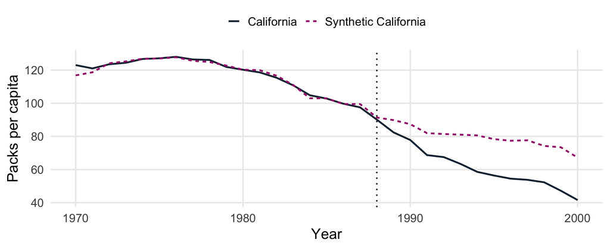

Source: corrected replication. Vertical line marks the last pretreatment year.

## The estimated effects are close to the paper

| Quantity | Paper | Replication |
| --- | --- | --- |
| Average reduction, 1989–2000 | Almost 20 packs | 18.85 packs |
| Percentage reduction | About 25% | 23.80% |
| Reduction in 2000 | About 26 packs | 25.58 packs |
| Pretreatment MSPE | About 3 | 3.17 |

**A close substantive replication, with numerical differences**

Sources: ADH (2010), Section 3.3 and abstract; corrected replication. Our percentage divides the average reduction by mean synthetic sales. Packs are annual sales per capita.

## California has the largest placebo ratio

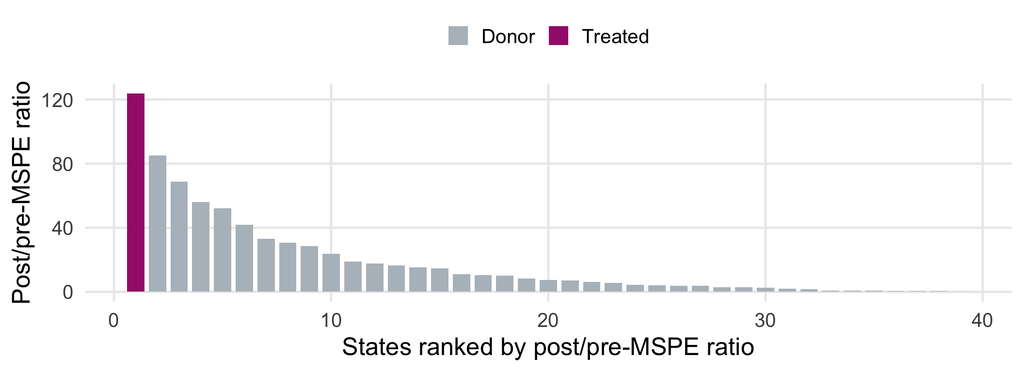

Independent predictor optimization: California ranks **1 of 39**, rank p = **0.0256**.

Source: `results/independent_placebos/`. Ratios measure squared divergence. The gap establishes the negative direction. This is a placebo comparison, not proof of random assignment.

## Placebo fitting choices change the sensitivity analysis

| Pre-MSPE cutoff | Default donors | Independent donors | Independent rank p |
| --- | --- | --- | --- |
| No cutoff | 38 | 38 | 0.0256 |
| 20× California | 29 | 32 | 0.0303 |
| 5× California | 20 | 28 | 0.0345 |
| 2× California | 6 | 18 | 0.0526 |

California remains first. At the strictest cutoff, 19 total states give a minimum p-value of **1/19**.

The default reuses California’s predictor weights. Independent fitting chooses them separately for each state. Published retained counts: 34, 29, 19. Sources: saved results; ADH (2010), Figures 5–7.

## Lessons and implications for our project

- Check package conventions and solver arguments before interpreting results
- Rebuild diagnostics from the current model to avoid stale results
- Inspect placebo fit as well as California’s estimated effect
- Report numerical differences and sensitivity transparently

**Project application:** identify the counterfactual, justify the comparison group, and assess robustness

Sales may differ from consumption through cross-border purchases or smuggling.

## Appendix: predictor balance

| variable | California | synthetic_California | donor_sample |
| --- | --- | --- | --- |
| age15to24 | 0.1735 | 0.1736 | 0.1725 |
| lnincome | 10.0766 | 9.8535 | 9.8292 |
| retprice | 89.4222 | 89.3908 | 87.2661 |
| beer | 24.2800 | 24.2225 | 23.6553 |
| cigsale_1975 | 127.1000 | 126.9914 | 136.9316 |
| cigsale_1980 | 120.2000 | 120.2205 | 138.0895 |
| cigsale_1988 | 90.1000 | 91.3889 | 113.8237 |

Age share uses proportions. The donor-sample average is unweighted. Log income has weaker balance and a small predictor weight.

Source: corrected replication; ADH (2010), Table 1.

## Appendix: sources and reproducibility

Abadie, A., Diamond, A., and Hainmueller, J. (2010). Synthetic control methods for comparative case studies: Estimating the effect of California’s tobacco control program. *JASA*, 105(490), 493–505. https://doi.org/10.1198/jasa.2009.ap08746

- Baseline: `code/01_replication.R`
- Independent placebos: `code/02_independent_placebos.R`
- Detailed update: `Replication_Update_for_Ying.qmd`
- Results: `results/tables/` and `results/independent_placebos/`

Appendix slides are outside the planned 10-minute narration.